# Interaction between ecosystem complexity and productivity in determining species richness

Zachary Foster

11/21/2014

A paper I read for class (Verschuyl, Hansen, McWethy, Sallabanks, and Hutto (2008)) explored the relationship between ecosystem complexity, productivity, and species richness. They proposed that complexity correlates with species richness at low-moderate productivity, but flattens/decreases with high productivity. They mention a theory that states that ecosystem productivity drives species richness because it allows for larger population sizes, which mitigate the bad effects of population fluctuations.

Another way of thinking about this in the context of ecosystem complexity is to think of an ecosystem subdivided (in function, not necessarily space) into niches, each producing a proportion of the total ecosystem productivity.

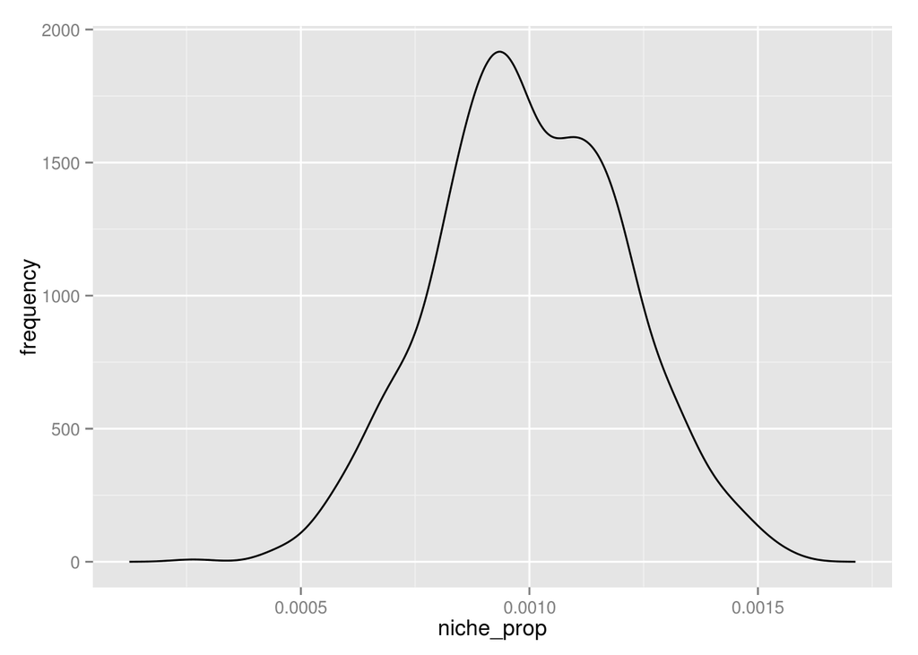

```r
niche_num <- 1000
data <- data.frame(niche_prop = rnorm(n = niche_num, mean = 10, sd = 2))
data$niche_prop <- data$niche_prop / sum(data$niche_prop)

dens <- with(density(data$niche_prop), data.frame(niche_prop = x, frequency = y))
ggplot(dens, aes(x = niche_prop, y = frequency)) +
  geom_line()
```

The total gpp of each niche would then be..

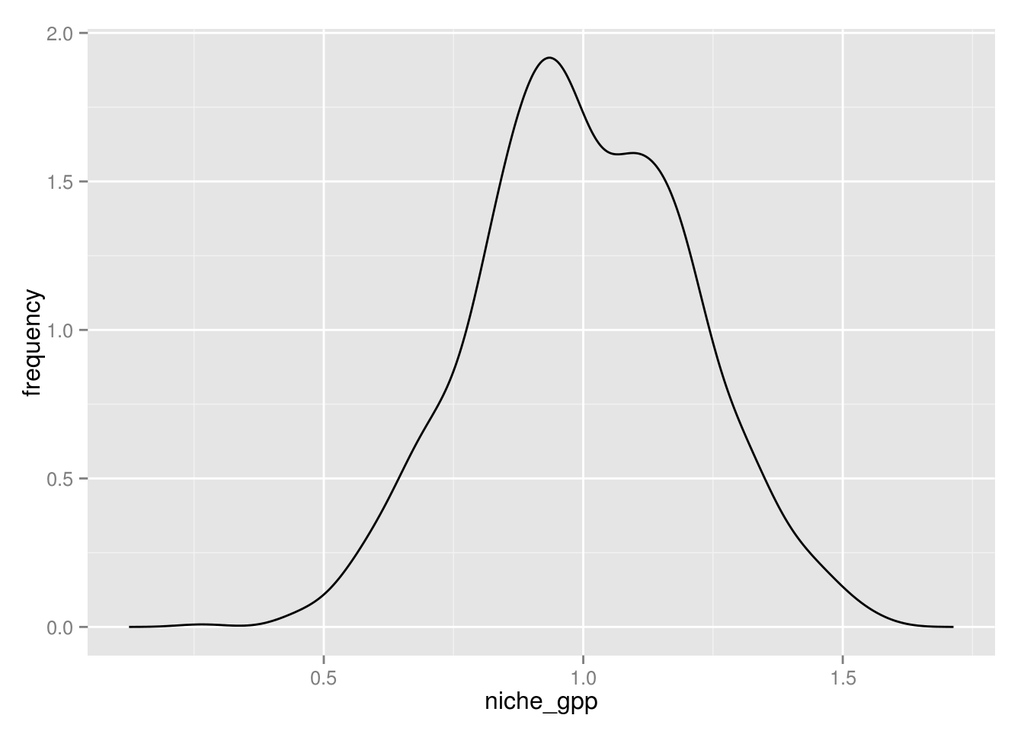

```r
total_gpp <- 1000
data$niche_gpp <- data$niche_prop * total_gpp
dens <- with(density(data$niche_gpp), data.frame(niche_gpp = x, frequency = y))
ggplot(dens, aes(x = niche_gpp, y = frequency)) +
  geom_line()
```

Lets assume, for simplicity, that all species have the same minimum population size and that the same amount of gpp is needed per individual. In that case, only niches with enough productivity to support at least one species population will contribute to speceis richness:

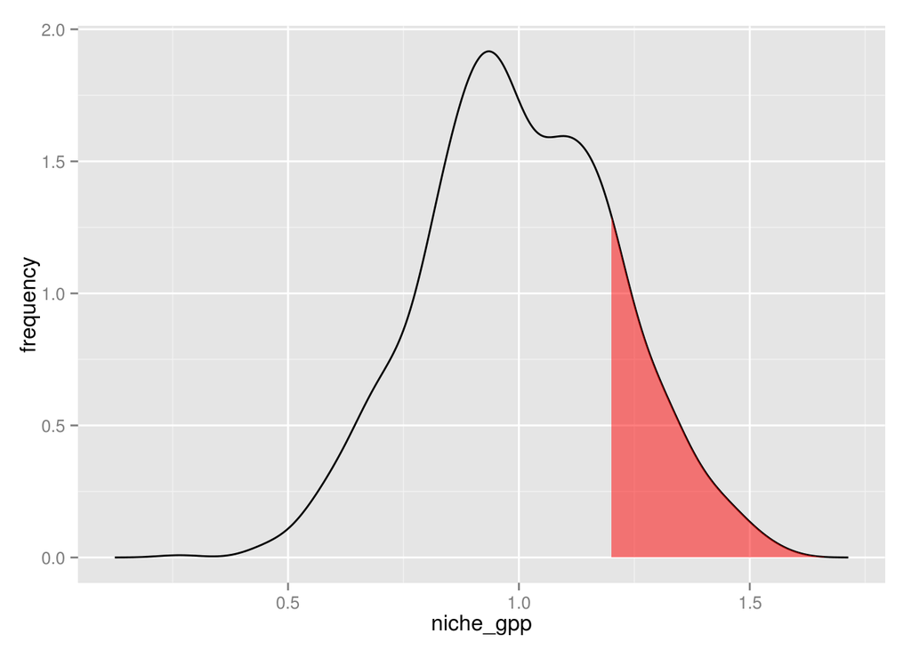

```r
gpp_per_individual <- 0.012
min_population_size <- 100
min_species_gpp <- min_population_size * gpp_per_individual

dens <- with(density(data$niche_gpp), data.frame(niche_gpp = x, frequency = y))
ggplot(dens, aes(x = niche_gpp, y = frequency)) +
  geom_line() +
  geom_ribbon(data = subset(dens, niche_gpp > min_species_gpp),
              aes(ymax = frequency), ymin = 0,
              fill = "red", colour = NA, alpha = 0.5)
```

```r
get_prop_of_usable_niches <- function(niche_prop, min_gpp, total_gpp) {
  niche_gpp <- niche_prop * total_gpp
  sum(niche_gpp >  min_gpp)
}
get_prop_of_usable_niches(data$niche_prop, min_species_gpp, total_gpp)
```

```
## [1] 171
```

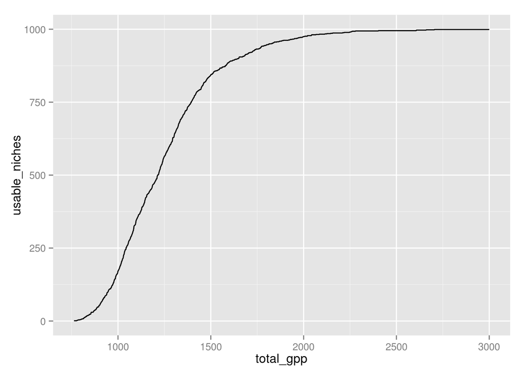

```r
gpp_range <- 500:3000
usable_niches <- sapply(gpp_range, function(x) get_prop_of_usable_niches(data$niche_prop, min_species_gpp, x))
usable_data <- data.frame(total_gpp = gpp_range, usable_niches = usable_niches)
usable_data <- subset(usable_data, usable_niches > 0 & usable_niches < niche_num)
ggplot(usable_data, aes(x = total_gpp, y = usable_niches)) +
  geom_line()
```